# Supercharging websites with a real-time R API

EARL London - 13th-15th September 2016

## Hello

- I'm Mark Edmondson (@HoloMarkeD)
- Englishman living in Copenhagen since 2010
- Data Insight Developer for IIH Nordic
- Google Developer Expert for Google Analytics
- RStudio Shiny Advocate

## Slow websites lose money

## Google and Bing study: ~1% loss of revenue for every 500ms slower

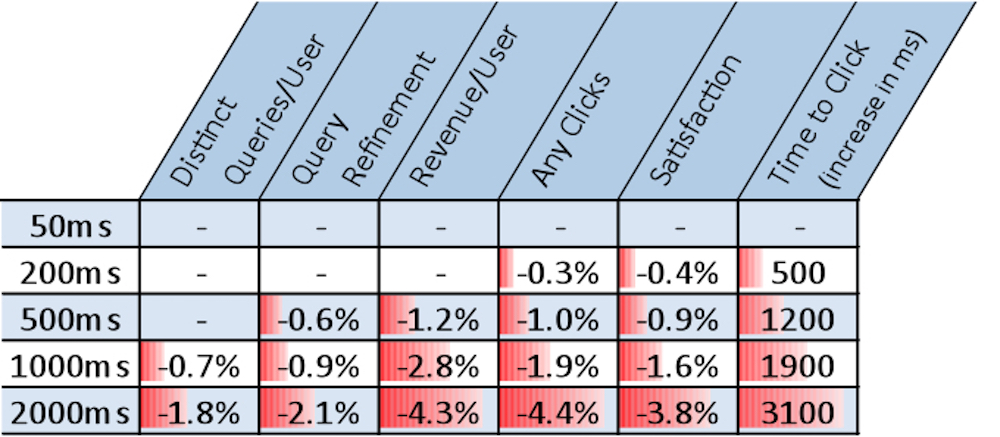

Source: [oreilly.com](http://radar.oreilly.com/2009/06/bing-and-google-agree-slow-pag.html)

## Why is Chrome so fast?

One reason is Google Chrome uses [prefetch](https://support.google.com/chrome/answer/1385029?hl=en)

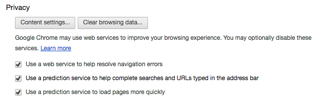

## Google Chrome's secret - it predicts your browsing and prefetches URL

[Prefetch tag](http://w3c.github.io/resource-hints/#prefetch) makes Chrome (and websites) faster by loading next page.

```html
<link rel="dns-prefetch" href="//widget.com">
<link rel="preconnect" href="//cdn.example.com">
<link rel="prefetch" href="//example.com/next-page.html">
<link rel="prerender" href="//example.com/thankyou.html">
```

And we can use it too - can be inserted dynamically:

```javascript
var hint = document.createElement("link")
hint.setAttribute("rel","prerender")
hint.setAttribute("href","next-page.html")
document.getElementsByTagName("head")[0].appendChild(hint)
```

## Prefetch browser coverage

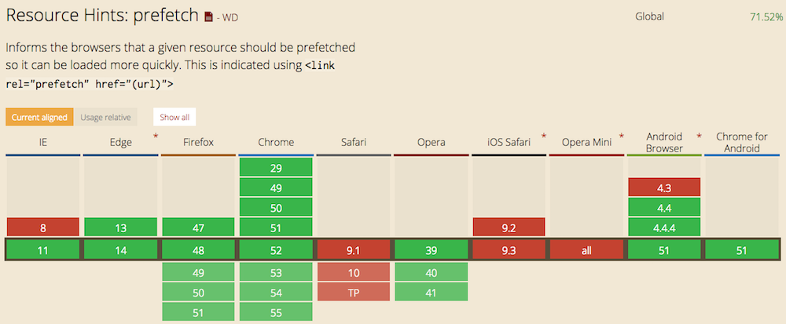

## Can R predict the next page?

```javascript
var hint = document.createElement("link")
hint.setAttribute("rel","prerender")

hint.setAttribute("href", "next-page.html")

document.getElementsByTagName("head")[0].appendChild(hint)
```

Can we predict quick enough to dynamically add it to the page before a user clicks?

- **Yes - using R, OpenCPU and Google Tag Manager**

## The deployment

OpenCPU and Google Tag Manager

## OpenCPU

- By Jeroen Ooms, rOpenScientist at UC Berkeley [@opencpu](http://twitter.com/opencpu)
- RaaS - R as a Service
- [An API for embedded scientific computing](https://www.opencpu.org/)
- Web server that turns R code into JSON
- Supporting JavaScript library
- A server that creates a RESTful web API
- Let R programmers create the models, front-end web developers handle the data
- See also: www.yhat.com, www.dominodatalab.com, [Plumber](http://plumber.trestletech.com/), [firey](https://github.com/thomasp85/fiery)

## Google Tag Manager

- Free [tag management system](https://www.google.com/analytics/tag-manager/) on Google infrastructure
- JavaScript container you can edit remotely
- DataLayer object to manage data in centralised manner
- Deploy analytics tracking, beacons or any JavaScript
- See also: DTM for Adobe Analytics, Tealium for paid features

## OpenCPU helps productionise your R code

- OpenCPU - used by your R team to come up with the models to a form a web developer can use
- Google Tag Manager lets you deploy OpenCPU output
- Only one method of deployment, a more stable execution would involve the client web development team working directly with the OpenCPU JSON
- But Google Tag Manager great for situations where you can't do that, or for proof of concept

## Data flow diagram

[figure not shown]

data architecture

## R - Creating the model

## Get Google Analytics Data

Extracting data per user using [`googleAnalyticsR`](http://code.markedmondson.me/googleAnalyticsR/)

```r
library(googleAnalyticsR)
ga_auth()
gaId <- xxxx # Your View ID

## In this case, dimension3 contains userId in format:
## u={cid}&t={hit-timestamp}
raw <- google_analytics_4(gaId,
                          date_range = c("2016-02-01","2016-02-01"),
                          metrics = c("pageviews"),
                          dimensions = c("dimension3", "pagePath"),
                          max = -1)
```

Or extract via BigQuery if you have Google Analytics 360 via `google_analytics_bq()`

## Raw Data

| dimension3 | pagePath | pageviews |
| --- | --- | --- |
| u=100116318.1454322382&t=1454322382033 | /example/809 | 1 |
| u=100116318.1454322382&t=1454322412130 | /example/1212 | 1 |
| u=100116318.1454322382&t=1454322431492 | /example/339 | 1 |
| u=100116318.1454322382&t=1454322441120 | /example/1494 | 1 |
| u=100116318.1454322382&t=1454322450156 | /example/339 | 1 |
| u=100116318.1454322382&t=1454322461871 | /example/1703 | 1 |

## GA data - after processing

| cid | sessionLen | timestamp | pagePath | pageviews |
| --- | --- | --- | --- | --- |
| 1005103157.1454327958 | 2 | 2016-02-01 12:59:18 | /example/1 | 1 |
| 1005103157.1454327958 | 2 | 2016-02-01 13:02:42 | /example/155 | 1 |
| 1010303050.1454327644 | 2 | 2016-02-01 12:54:03 | /example/144 | 1 |
| 1010303050.1454327644 | 2 | 2016-02-01 13:00:03 | /example/80 | 1 |
| 1011007665.1454333263 | 2 | 2016-02-01 14:27:43 | /example/1359 | 1 |

## GA data - fit for model

Our model library `markovchain` needs a vector of sequential pageviews per userId.

```r
## for each cid, split pagePath in timestamp order
sequenceVD <- processed %>% select(cid, timestamp, pagePath) %>%
  group_by(cid) %>% arrange(timestamp) %>%
  distinct(pagePath) %>%
  mutate(step = row_number(), n = n()) %>% arrange(cid) %>%
  filter(n > 1) %>% select(-n) %>%
  spread(step, pagePath)
```

## Model data

| cid | 1 | 2 | 3 | 4 |
| --- | --- | --- | --- | --- |
| 1000641120.1465683551 | /da/a-z/6236/2665 | /da/a-z/6236/2670 | NA | NA |
| 1001334948.1469706364 | /da/a-z/6236/2660 | /da/a-z/6236 | NA | NA |
| 1003589990.1471286236 | /da/a-z/6236/2707 | /da/a-z/6236/2660 | NA | NA |
| 1003723352.1470269948 | /da/a-z/6236/2707 | /da/a-z/6236/2660 | NA | NA |
| 1004139521.1469437411 | /da/a-z/6236/2660 | /da/a-z/6236/2707 | NA | NA |
| 1004647640.1468402554 | /da/a-z/6236/2678 | /da/a-z/6236/2714 | /da/a-z/6236/2670 | NA |

## Create Model

Create a Markov chain model of first order

```r
library(markovchain)

model <- markovchainListFit(sequenceVD[,2:10], name = "seq")

## save model for use on OpenCPU
save(model, file="./data/model.rda")
```

## Using model for predictions

Predictions now we have built the model object.

```r
library(markovchain)

## make predictions
predict(model$estimate, newdata = "/da/a-z/6236/2665")

## prediction output
Sequence: /example/251
```

## Visualisation of the model

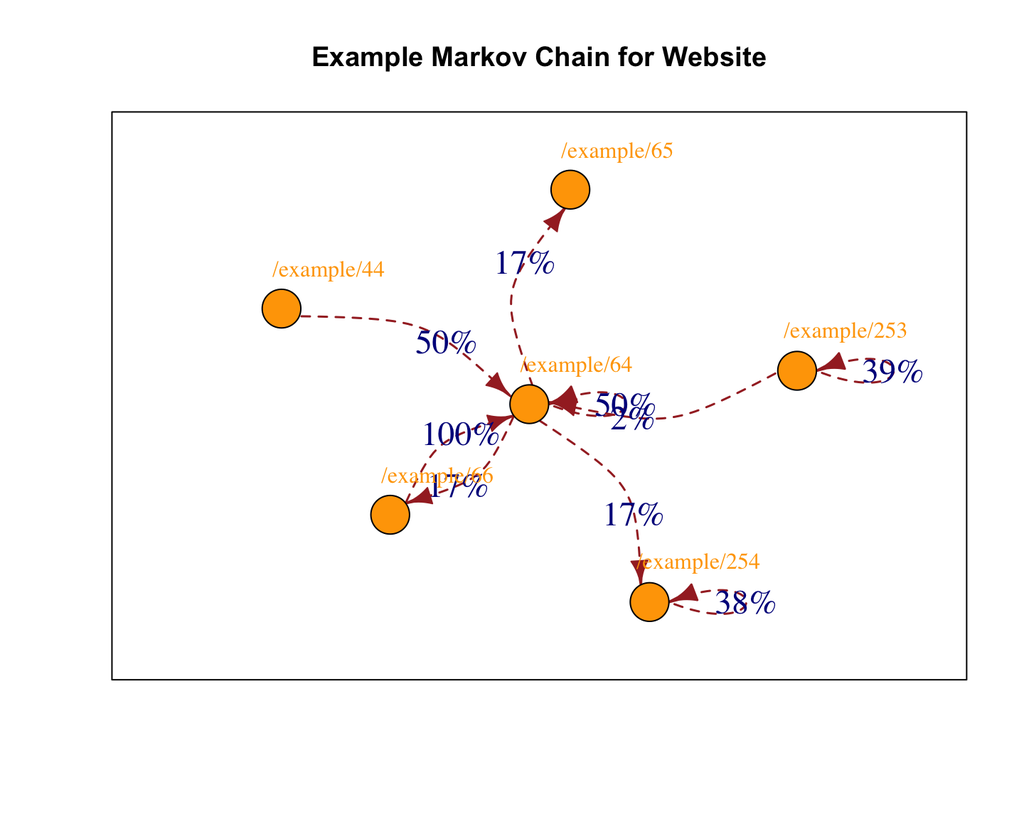

## Deploying to OpenCPU via Github

OpenCPU allows webhooks to Github: updates the model everytime you push to Github

Create a small custom package with the model data and the function to predict pageviews

```r
predictNextPage <- function(current_url){
  out <- try(predict(model, newdata = current_url), silent = TRUE)
  if(inherits(out, "try-error")){
    out <- "None"
  }
  out
}
```

## Example package for loading model prediction into OpenCPU

An example library using the predict function and the model data is here:

https://github.com/MarkEdmondson1234/predictClickOpenCPU

This library is called on the OpenCPU server from Google Tag Manager

## Calling OpenCPU

Test your OpenCPU calls here: https://public.opencpu.org/ocpu/test/

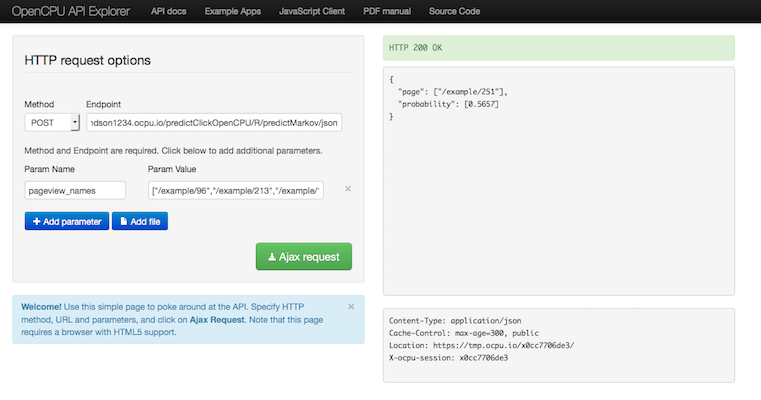

## Using GTM

Google Tag Manager lets you deploy JavaScript to a website without needing IT resources.

Login via a web interface: https://www.google.com/analytics/tag-manager/

[figure not shown]

## GTM calling OpenCPU

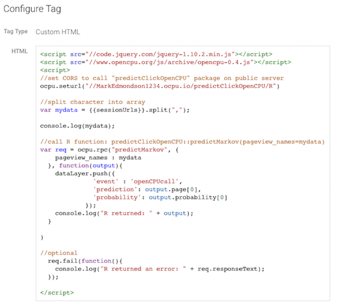

## GTM Add Prefetch

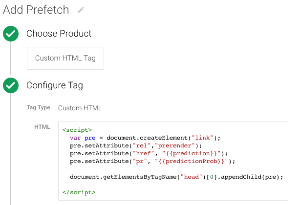

## Putting it into practice

## Demo website

http://code.markedmondson.me/predictClickOpenCPU/example/107.html

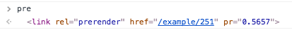

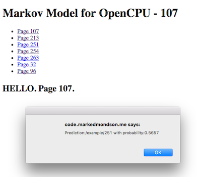

## Test prerender

In Chrome go to chrome://net-internals#prerender

[figure not shown]

## Client website

## Preliminary results

[interactive chart not shown]

## Summary

- R can speed up websites via prefetch prediction
- OpenCPU turns R into JSON, GTM deploys JSON onto websites easily
- R can be quickly deployed through GTM to act upon realtime website data
- Page prediction just one application of this data infrastructure

## Further work

- Tune the model
- Feed R forecasts into DMPs, AdWords, Display
- Client auto-segmentation for content recommendations
- Have you any ideas of applications?

## Thank You

Questions?

- Credit and thanks to [Vincent Terrasi](https://data-seo.com/) for prefetching idea.
- Say hello on Twitter: [@HoloMarkeD](http://twitter.com/HoloMarkeD)
- Read my blog: http://markedmondson.me
- Code and examples are at http://code.markedmondson.me/predictClickOpenCPU/
- Contact [IIH Nordic](http://iihnoric.com) if you'd like to implement this